**Title: Statistical Modeling Assignment 2**

**Group : 9**

1) Exploratory data analysis (EDA). Explore the bank_trn.csv data using any means necessary.  
Based on your exploration and basic intuition, which variables (if any) seem to be associated with the response? If you had to pick the top three variables in terms of their degree of association to the response, which would you choose (be sure to include your reasoning for choosing these variables)? Please include any useful visualizations and/or statistics (i.e., frequency tables) as evidence to your hypotheses.

```r
bank_trn <- read.csv("D:/Statsical modelling/Home work 2/bank_trn.csv")
library(magrittr)
library(tidyverse)
summary(bank_trn)
```

```
##       age            job              marital           education
##  Min.   :17.00   Length:37070       Length:37070       Length:37070
##  1st Qu.:32.00   Class :character   Class :character   Class :character
##  Median :38.00   Mode  :character   Mode  :character   Mode  :character
##  Mean   :40.04
##  3rd Qu.:47.00
##  Max.   :98.00
##    default            housing              loan             contact
##  Length:37070       Length:37070       Length:37070       Length:37070
##  Class :character   Class :character   Class :character   Class :character
##  Mode  :character   Mode  :character   Mode  :character   Mode  :character
##
##
##
##     month           day_of_week           duration         campaign
##  Length:37070       Length:37070       Min.   :   0.0   Min.   : 1.000
##  Class :character   Class :character   1st Qu.: 102.0   1st Qu.: 1.000
##  Mode  :character   Mode  :character   Median : 180.0   Median : 2.000
##                                        Mean   : 258.5   Mean   : 2.565
##                                        3rd Qu.: 320.0   3rd Qu.: 3.000
##                                        Max.   :4918.0   Max.   :56.000
##      pdays          previous        poutcome          emp_var_rate
##  Min.   :  0.0   Min.   :0.0000   Length:37070       Min.   :-3.40000
##  1st Qu.:999.0   1st Qu.:0.0000   Class :character   1st Qu.:-1.80000
##  Median :999.0   Median :0.0000   Mode  :character   Median : 1.10000
##  Mean   :962.2   Mean   :0.1737                      Mean   : 0.08046
##  3rd Qu.:999.0   3rd Qu.:0.0000                      3rd Qu.: 1.40000
##  Max.   :999.0   Max.   :6.0000                      Max.   : 1.40000
##  cons_price_idx  cons_conf_idx      euribor3m      nr_employed
##  Min.   :92.20   Min.   :-50.80   Min.   :0.634   Min.   :4964
##  1st Qu.:93.08   1st Qu.:-42.70   1st Qu.:1.344   1st Qu.:5099
##  Median :93.75   Median :-41.80   Median :4.857   Median :5191
##  Mean   :93.58   Mean   :-40.49   Mean   :3.620   Mean   :5167
##  3rd Qu.:93.99   3rd Qu.:-36.40   3rd Qu.:4.961   3rd Qu.:5228
##  Max.   :94.77   Max.   :-26.90   Max.   :5.045   Max.   :5228
##   subscribed
##  Length:37070
##  Class :character
##  Mode  :character
##
##
##
```

Visualizations of data

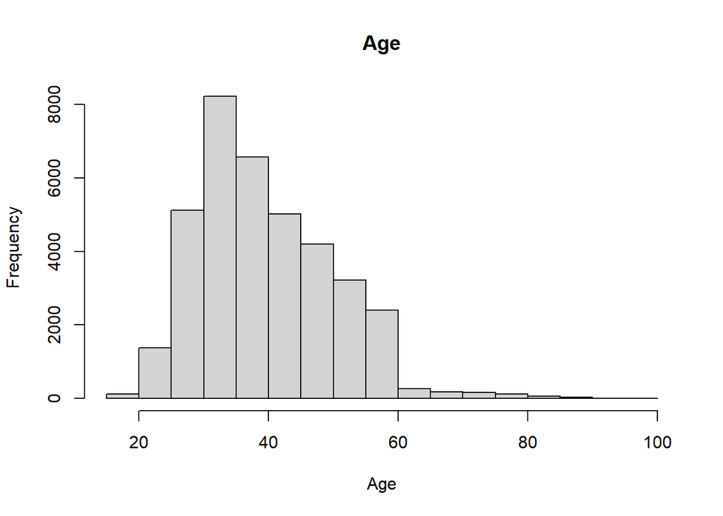

```r
hist(bank_trn$age, main = "Age", xlab = "Age")
```

Most of the people are aged between 25 years to 50 years.

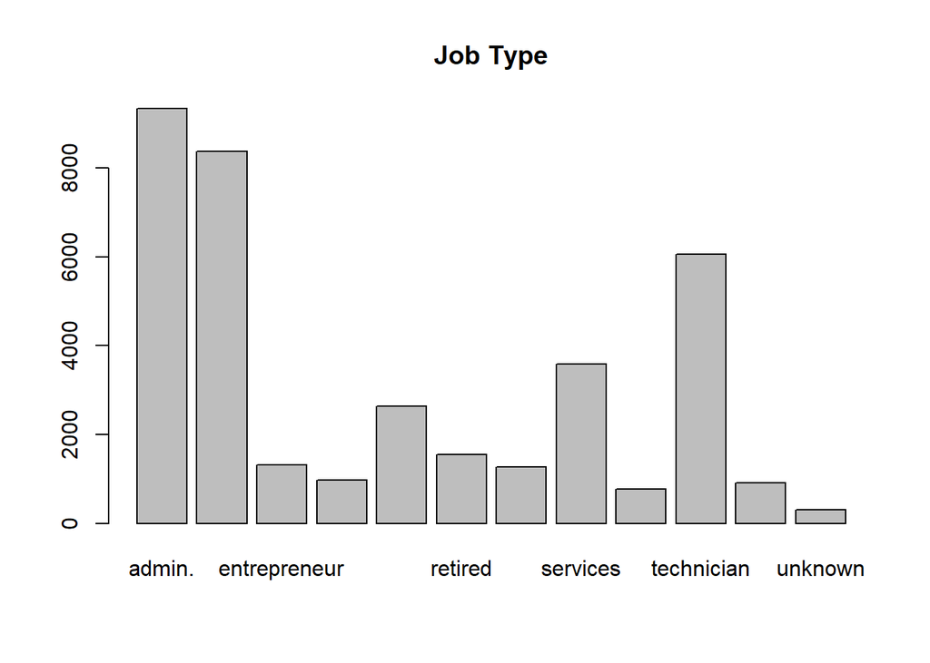

```r
barplot(table(bank_trn$job), main = "Job Type")
```

Most of the people are occupied in the jobs admin, blue-collar and technician.

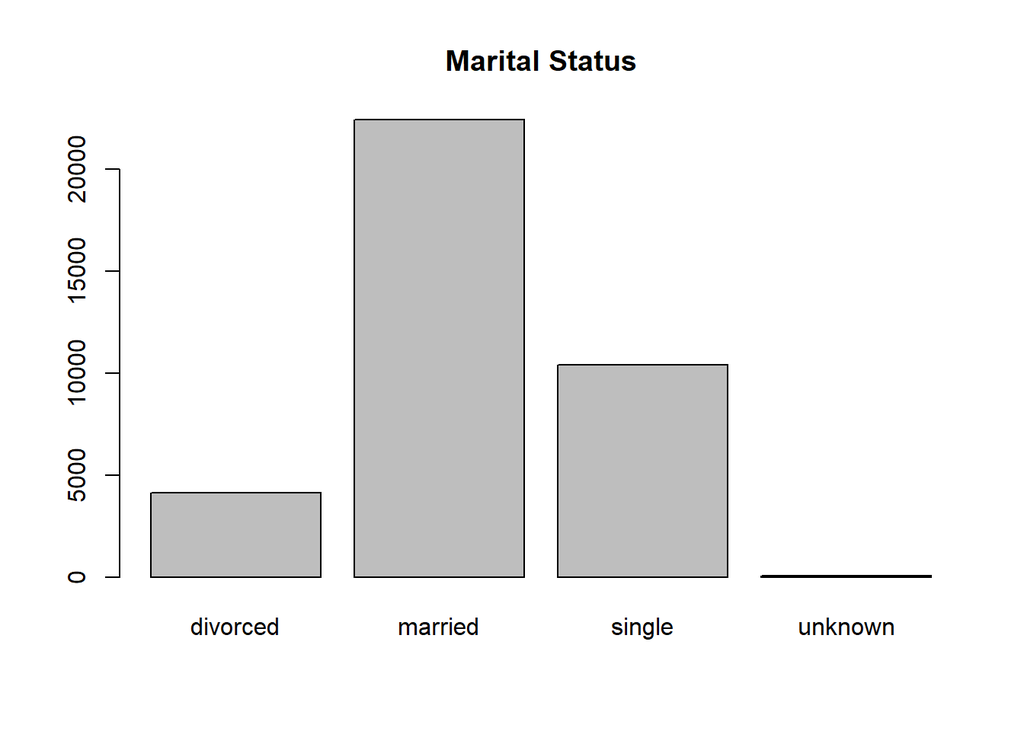

```r
barplot(table(bank_trn$marital), main = "Marital Status")
```

Most of the people are married or single.

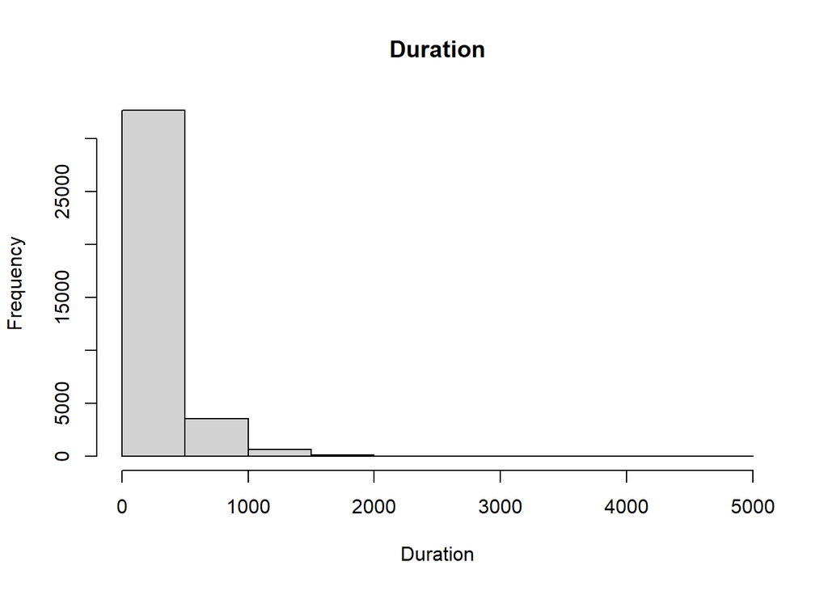

```r
hist(bank_trn$duration, main = "Duration", xlab = "Duration")
```

In most of the calls the duration is less that 500 seconds. Some are between 500 seconds and 1000 seconds.

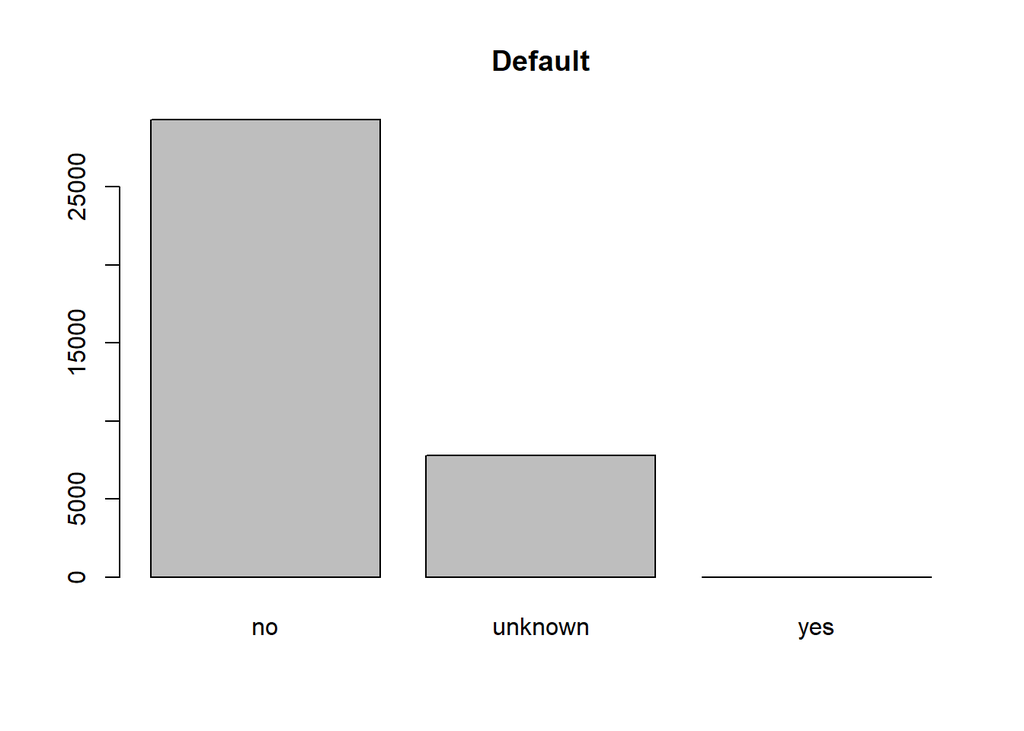

```r
barplot(table(bank_trn$default), main = "Default")
```

Most of the people had no Loan Default status history. While there are few people about whom no information is known.

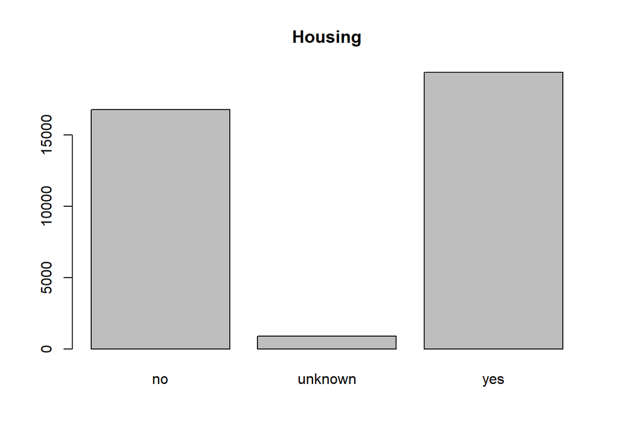

```r
barplot(table(bank_trn$housing), main = "Housing")
```

The number of people with house loan and number of people without house loan are almost same.

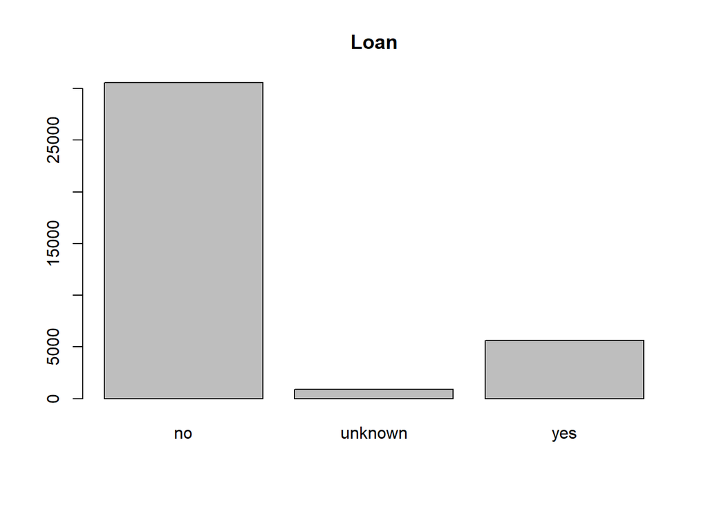

```r
barplot(table(bank_trn$loan), main = "Loan")
```

Number of people without a personal loan more than the number of people with personal loan.

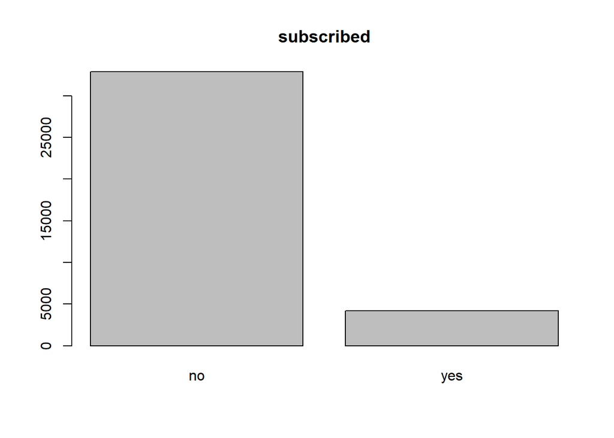

```r
barplot(table(bank_trn$subscribed), main = "subscribed")
```

Correlation check:

```r
bank_trn$subscribed <- ifelse(bank_trn$subscribed == "yes", 1, 0)

numeric_vars <- bank_trn[, sapply(bank_trn, is.numeric)]

cor_matrix <- cor(numeric_vars, use = "pairwise.complete.obs")

cor_matrix
```

```
##                          age     duration     campaign       pdays    previous
## age             1.0000000000 -0.002549458  0.005603469 -0.03402474  0.02579007
## duration       -0.0025494578  1.000000000 -0.071679318 -0.05041004  0.02249163
## campaign        0.0056034694 -0.071679318  1.000000000  0.05288085 -0.07856275
## pdays          -0.0340247426 -0.050410037  0.052880849  1.00000000 -0.58560861
## previous        0.0257900667  0.022491632 -0.078562754 -0.58560861  1.00000000
## emp_var_rate   -0.0031540460 -0.026787641  0.148900864  0.27248751 -0.42203170
## cons_price_idx -0.0002705845  0.005901002  0.126553986  0.08186301 -0.20493662
## cons_conf_idx   0.1302155970 -0.009439247 -0.014711345 -0.09398889 -0.05180533
## euribor3m       0.0074926358 -0.032509062  0.133161797  0.29773096 -0.45602403
## nr_employed    -0.0211575951 -0.043780879  0.142211605  0.37315125 -0.50243762
## subscribed      0.0333854838  0.403485639 -0.065652628 -0.32879646  0.23265696
##                emp_var_rate cons_price_idx cons_conf_idx    euribor3m
## age            -0.003154046  -0.0002705845   0.130215597  0.007492636
## duration       -0.026787641   0.0059010021  -0.009439247 -0.032509062
## campaign        0.148900864   0.1265539861  -0.014711345  0.133161797
## pdays           0.272487512   0.0818630136  -0.093988885  0.297730959
## previous       -0.422031704  -0.2049366198  -0.051805326 -0.456024029
## emp_var_rate    1.000000000   0.7766177470   0.193895583  0.972288797
## cons_price_idx  0.776617747   1.0000000000   0.057914550  0.689573300
## cons_conf_idx   0.193895583   0.0579145496   1.000000000  0.276005738
## euribor3m       0.972288797   0.6895732996   0.276005738  1.000000000
## nr_employed     0.906900520   0.5233996810   0.098593666  0.945026027
## subscribed     -0.299184700  -0.1384587934   0.054963071 -0.308767847
##                nr_employed  subscribed
## age            -0.02115760  0.03338548
## duration       -0.04378088  0.40348564
## campaign        0.14221160 -0.06565263
## pdays           0.37315125 -0.32879646
## previous       -0.50243762  0.23265696
## emp_var_rate    0.90690052 -0.29918470
## cons_price_idx  0.52339968 -0.13845879
## cons_conf_idx   0.09859367  0.05496307
## euribor3m       0.94502603 -0.30876785
## nr_employed     1.00000000 -0.35496357
## subscribed     -0.35496357  1.00000000
```

Top 3 most correlated with subscribed response are:

Highly correlated with Duration with a correlation of 0.403485639

The next variable Nr_employed is correlated with a correlation of -0.35496357

Pdays is the variable which is correlated to subscription with a correlation of -0.32879646

```r
cat<- bank_trn[, sapply(bank_trn, is.character)]
p_values <- sapply(names(cat), function(var)
  {
  if (var != "subscribed") {
    chisq.test(table(bank_trn$subscribed, cat[, var]))$p.value
  }
})
p_values <- p_values[!sapply(p_values, is.null)]

p_values_df <- data.frame(Variable = names(p_values), P_Value = unlist(p_values))

sorted_p_values_df <- p_values_df[order(p_values_df$P_Value), ]

sorted_p_values_df
```

```
##                Variable       P_Value
## month             month  0.000000e+00
## poutcome       poutcome  0.000000e+00
## job                 job 2.016626e-181
## contact         contact 5.175810e-174
## default         default  1.183237e-80
## education     education  2.255866e-34
## marital         marital  1.456943e-23
## day_of_week day_of_week  8.776899e-05
## housing         housing  3.630020e-02
## loan               loan  2.003532e-01
```

The three categorical variables that have more correlation to the subscribed status are

month, poutcome and job.

**2). Initial modeling. Based on your results from 1) fit an initial logistic regression model to the data. Does the model fit appear reasonable? Please explain using relevant graphics and/or statistics (e.g., how does it compare to the null model or a model that always predicts “no”?).**

```r
library(glmnet)
model1 <- glm(subscribed ~ duration + pdays + month, data = bank_trn, family = binomial)
summary(model1)
```

```
##
## Call:
## glm(formula = subscribed ~ duration + pdays + month, family = binomial,
##     data = bank_trn)
##
## Coefficients:
##               Estimate Std. Error z value Pr(>|z|)
## (Intercept) -1.706e-01  8.892e-02  -1.918   0.0551 .
## duration     4.119e-03  6.891e-05  59.765  < 2e-16 ***
## pdays       -2.780e-03  6.901e-05 -40.282  < 2e-16 ***
## monthaug    -7.036e-01  7.856e-02  -8.956  < 2e-16 ***
## monthdec     1.014e+00  2.017e-01   5.026 5.00e-07 ***
## monthjul    -1.106e+00  7.921e-02 -13.964  < 2e-16 ***
## monthjun    -7.226e-01  8.115e-02  -8.905  < 2e-16 ***
## monthmar     1.689e+00  1.187e-01  14.230  < 2e-16 ***
## monthmay    -1.439e+00  7.345e-02 -19.591  < 2e-16 ***
## monthnov    -9.160e-01  8.805e-02 -10.403  < 2e-16 ***
## monthoct     1.018e+00  1.146e-01   8.883  < 2e-16 ***
## monthsep     8.086e-01  1.276e-01   6.338 2.33e-10 ***
## ---
## Signif. codes:  0 '***' 0.001 '**' 0.01 '*' 0.05 '.' 0.1 ' ' 1
##
## (Dispersion parameter for binomial family taken to be 1)
##
##     Null deviance: 26099  on 37069  degrees of freedom
## Residual deviance: 17867  on 37058  degrees of freedom
## AIC: 17891
##
## Number of Fisher Scoring iterations: 6
```

```r
null_model <- glm(subscribed ~ 1, data = bank_trn , family = binomial)
AIC(model1)
```

```
## [1] 17890.64
```

```r
AIC(null_model)
```

```
## [1] 26101.04
```

1. **Null Deviance:** The null deviance is 26099 on 37069 degrees of freedom.
2. **Residual Deviance:** The residual deviance is 17867 on 37058 degrees of freedom.
3. **AIC:** The AIC for the initial model is 17891

The less deviance in initial model when compared to the null model with predictors provides a better fit with less AIC.

3). Using the stepAIC() function from package MASS, fit several additional models for comparison (see?MASS::stepAIC for additional details):  
• Starting from your initial model, use stepAIC() and specify direction = “both” (the default).  
Is the resulting model different? If it is, how so (e.g., did stepAIC() drop terms, include new ones, or both)? Which model seems better in terms of prediction accuracy?

```r
library(MASS)
step_model1 <- stepAIC(model1, direction = "both")
```

```
## Start:  AIC=17890.64
## subscribed ~ duration + pdays + month
##
##            Df Deviance   AIC
## <none>           17867 17891
## - month     9    19331 19337
## - pdays     1    19483 19505
## - duration  1    22531 22553
```

```r
summary(step_model1)
```

```
##
## Call:
## glm(formula = subscribed ~ duration + pdays + month, family = binomial,
##     data = bank_trn)
##
## Coefficients:
##               Estimate Std. Error z value Pr(>|z|)
## (Intercept) -1.706e-01  8.892e-02  -1.918   0.0551 .
## duration     4.119e-03  6.891e-05  59.765  < 2e-16 ***
## pdays       -2.780e-03  6.901e-05 -40.282  < 2e-16 ***
## monthaug    -7.036e-01  7.856e-02  -8.956  < 2e-16 ***
## monthdec     1.014e+00  2.017e-01   5.026 5.00e-07 ***
## monthjul    -1.106e+00  7.921e-02 -13.964  < 2e-16 ***
## monthjun    -7.226e-01  8.115e-02  -8.905  < 2e-16 ***
## monthmar     1.689e+00  1.187e-01  14.230  < 2e-16 ***
## monthmay    -1.439e+00  7.345e-02 -19.591  < 2e-16 ***
## monthnov    -9.160e-01  8.805e-02 -10.403  < 2e-16 ***
## monthoct     1.018e+00  1.146e-01   8.883  < 2e-16 ***
## monthsep     8.086e-01  1.276e-01   6.338 2.33e-10 ***
## ---
## Signif. codes:  0 '***' 0.001 '**' 0.01 '*' 0.05 '.' 0.1 ' ' 1
##
## (Dispersion parameter for binomial family taken to be 1)
##
##     Null deviance: 26099  on 37069  degrees of freedom
## Residual deviance: 17867  on 37058  degrees of freedom
## AIC: 17891
##
## Number of Fisher Scoring iterations: 6
```

In summary, the stepwise model selection did not lead to any changes in the model structure. The initial model with predictors “duration,” “pdays,” and “month” remains the same. The AIC and deviance values also remain consistent. This suggests that, based on the stepwise selection process, the initial model is considered suitable, and no additional predictors are needed.

• **Starting with an intercept only model, use stepAIC() to perform forward selection (i.e., direction= “forward”). What is the final model? Does it differ substantially from your initial model or the stepAIC() model from the previous step? How many parameters does this model have? (Hint:think about what happens to categorical variables in a logistic or ordinary linear regression model.)**

```r
scope1 <- list(lower = null_model, upper = glm(subscribed ~ ., data = bank_trn, family = binomial))

model_forward <- stepAIC(null_model, direction = "forward", scope = scope1, trace = FALSE)

summary(model_forward)
```

```
##
## Call:
## glm(formula = subscribed ~ duration + nr_employed + month + poutcome +
##     emp_var_rate + job + cons_price_idx + contact + euribor3m +
##     default + pdays + day_of_week + campaign + cons_conf_idx,
##     family = binomial, data = bank_trn)
##
## Coefficients:
##                       Estimate Std. Error z value Pr(>|z|)
## (Intercept)         -1.933e+02  4.030e+01  -4.796 1.62e-06 ***
## duration             4.690e-03  7.847e-05  59.761  < 2e-16 ***
## nr_employed          2.309e-03  3.271e-03   0.706 0.480345
## monthaug             7.933e-01  1.270e-01   6.244 4.26e-10 ***
## monthdec             2.739e-01  2.222e-01   1.233 0.217550
## monthjul             1.502e-01  1.011e-01   1.486 0.137238
## monthjun            -3.832e-01  1.326e-01  -2.889 0.003868 **
## monthmar             1.917e+00  1.516e-01  12.642  < 2e-16 ***
## monthmay            -4.877e-01  8.677e-02  -5.620 1.91e-08 ***
## monthnov            -4.519e-01  1.273e-01  -3.549 0.000387 ***
## monthoct             1.023e-01  1.624e-01   0.630 0.528615
## monthsep             2.525e-01  1.890e-01   1.336 0.181501
## poutcomenonexistent  4.990e-01  6.741e-02   7.402 1.34e-13 ***
## poutcomesuccess      1.031e+00  2.130e-01   4.839 1.30e-06 ***
## emp_var_rate        -1.614e+00  1.504e-01 -10.738  < 2e-16 ***
## jobblue-collar      -3.161e-01  6.951e-02  -4.548 5.42e-06 ***
## jobentrepreneur     -1.630e-01  1.309e-01  -1.245 0.213115
## jobhousemaid        -2.855e-02  1.440e-01  -0.198 0.842791
## jobmanagement        1.964e-02  8.730e-02   0.225 0.822016
## jobretired           2.792e-01  8.783e-02   3.179 0.001478 **
## jobself-employed    -8.896e-02  1.226e-01  -0.726 0.468116
## jobservices         -1.793e-01  8.633e-02  -2.077 0.037818 *
## jobstudent           1.879e-01  1.088e-01   1.727 0.084189 .
## jobtechnician        8.600e-03  6.709e-02   0.128 0.898003
## jobunemployed       -4.846e-02  1.345e-01  -0.360 0.718530
## jobunknown           3.029e-02  2.360e-01   0.128 0.897884
## cons_price_idx       1.894e+00  2.656e-01   7.131 9.94e-13 ***
## contacttelephone    -6.203e-01  8.014e-02  -7.740 9.96e-15 ***
## euribor3m            3.851e-01  1.366e-01   2.820 0.004808 **
## defaultunknown      -3.153e-01  6.983e-02  -4.516 6.30e-06 ***
## defaultyes          -7.356e+00  1.134e+02  -0.065 0.948268
## pdays               -8.582e-04  2.126e-04  -4.038 5.40e-05 ***
## day_of_weekmon      -1.119e-01  6.971e-02  -1.606 0.108351
## day_of_weekthu       5.769e-02  6.758e-02   0.854 0.393239
## day_of_weektue       1.279e-01  6.906e-02   1.851 0.064116 .
## day_of_weekwed       1.549e-01  6.944e-02   2.230 0.025720 *
## campaign            -3.691e-02  1.204e-02  -3.066 0.002166 **
## cons_conf_idx        1.554e-02  8.122e-03   1.913 0.055775 .
## ---
## Signif. codes:  0 '***' 0.001 '**' 0.01 '*' 0.05 '.' 0.1 ' ' 1
##
## (Dispersion parameter for binomial family taken to be 1)
##
##     Null deviance: 26099  on 37069  degrees of freedom
## Residual deviance: 15403  on 37032  degrees of freedom
## AIC: 15479
##
## Number of Fisher Scoring iterations: 10
```

The model differs substantially from both the initial model and the stepAIC() model from the previous step. The forward selection procedure has chosen a subset of predictors that contribute to explaining the variation in the response variable. Some predictors have been dropped during the forward selection based on their significance and contribution to model fit. The AIC value is lower than in the initial model, indicating an improved model fit.

The model shows it has 37 parameters but it contains duplicate values as the categorical variables would appear multiple times due to multiple levels.

**• Starting with a full model (i.e., a model with all possible predictors of interest), perform backward elimination by calling stepAIC() with direction = “backward. What is the result of the final model? Does it differ substantially from any of the previous models? If so, how?**

```r
model_result <- glm(subscribed ~ ., data = bank_trn, family = binomial)

model_backward <- stepAIC(model_result, direction = "backward", trace = FALSE)
summary(model_backward)
```

```
##
## Call:
## glm(formula = subscribed ~ job + default + contact + month +
##     day_of_week + duration + campaign + pdays + poutcome + emp_var_rate +
##     cons_price_idx + cons_conf_idx + euribor3m, family = binomial,
##     data = bank_trn)
##
## Coefficients:
##                       Estimate Std. Error z value Pr(>|z|)
## (Intercept)         -1.659e+02  1.093e+01 -15.180  < 2e-16 ***
## jobblue-collar      -3.145e-01  6.948e-02  -4.526 6.00e-06 ***
## jobentrepreneur     -1.608e-01  1.309e-01  -1.228  0.21935
## jobhousemaid        -2.872e-02  1.439e-01  -0.200  0.84184
## jobmanagement        1.982e-02  8.730e-02   0.227  0.82043
## jobretired           2.807e-01  8.779e-02   3.197  0.00139 **
## jobself-employed    -8.978e-02  1.226e-01  -0.732  0.46404
## jobservices         -1.789e-01  8.634e-02  -2.073  0.03821 *
## jobstudent           1.884e-01  1.088e-01   1.732  0.08333 .
## jobtechnician        7.282e-03  6.706e-02   0.109  0.91353
## jobunemployed       -4.859e-02  1.345e-01  -0.361  0.71780
## jobunknown           2.996e-02  2.361e-01   0.127  0.89900
## defaultunknown      -3.147e-01  6.983e-02  -4.507 6.57e-06 ***
## defaultyes          -7.364e+00  1.134e+02  -0.065  0.94822
## contacttelephone    -6.055e-01  7.715e-02  -7.848 4.22e-15 ***
## monthaug             7.527e-01  1.133e-01   6.644 3.05e-11 ***
## monthdec             2.196e-01  2.083e-01   1.054  0.29183
## monthjul             1.486e-01  1.010e-01   1.472  0.14103
## monthjun            -3.332e-01  1.121e-01  -2.972  0.00296 **
## monthmar             1.855e+00  1.231e-01  15.067  < 2e-16 ***
## monthmay            -5.112e-01  8.008e-02  -6.384 1.73e-10 ***
## monthnov            -4.935e-01  1.128e-01  -4.374 1.22e-05 ***
## monthoct             3.426e-02  1.308e-01   0.262  0.79331
## monthsep             1.613e-01  1.379e-01   1.169  0.24221
## day_of_weekmon      -1.134e-01  6.968e-02  -1.628  0.10362
## day_of_weekthu       5.823e-02  6.756e-02   0.862  0.38876
## day_of_weektue       1.252e-01  6.896e-02   1.816  0.06941 .
## day_of_weekwed       1.530e-01  6.939e-02   2.205  0.02743 *
## duration             4.690e-03  7.847e-05  59.770  < 2e-16 ***
## campaign            -3.685e-02  1.204e-02  -3.061  0.00221 **
## pdays               -8.578e-04  2.125e-04  -4.036 5.44e-05 ***
## poutcomenonexistent  4.971e-01  6.735e-02   7.381 1.58e-13 ***
## poutcomesuccess      1.030e+00  2.130e-01   4.836 1.33e-06 ***
## emp_var_rate        -1.551e+00  1.200e-01 -12.916  < 2e-16 ***
## cons_price_idx       1.725e+00  1.133e-01  15.221  < 2e-16 ***
## cons_conf_idx        1.150e-02  5.772e-03   1.993  0.04625 *
## euribor3m            4.571e-01  9.089e-02   5.030 4.92e-07 ***
## ---
## Signif. codes:  0 '***' 0.001 '**' 0.01 '*' 0.05 '.' 0.1 ' ' 1
##
## (Dispersion parameter for binomial family taken to be 1)
##
##     Null deviance: 26099  on 37069  degrees of freedom
## Residual deviance: 15404  on 37033  degrees of freedom
## AIC: 15478
##
## Number of Fisher Scoring iterations: 10
```

The final model includes various predictors like job, default, contact, month, day_of_week, duration, campaign, pdays, poutcome, emp_var_rate, cons_price_idx, cons_conf_idx, and euribor3m.

The final model after backward elimination has 36 variables, with duplicate variables due to categorical variables.

• Explore models that include 2-way interaction effects. There are several ways to do this. For  
example, in forward selection, you can allow for 2-way interaction effects in stepAIC() by using the scope argument. Does it seem necessary or beneficial to include any 2-way interaction effects in this example? If so, which interaction effects seem relevant and predictive?

```r
#result_forward_backward <- glm(subscribed ~ .^2, data = bank_trn, family = binomial)
```

```r
#scope2 <- list(lower = null_model1, upper = result_forward_backward)

#two_way_interaction <- stepAIC(null_model1, direction = "forward", scope = scope2, trace=FALSE)
```

```r
#summary(two_way_interaction)
```

An attempt was made to explore the model with 2-way interaction ways. The above code written to allow for 2-way interaction effects in stepAIC() by using the scope argument ran without an end and did not provide any outputs.

**4) Which of the models from 2)–3) seem the most useful for prediction? Which seem the most useful for description (e.g., understanding relationships and explainability)? How might your selected model(s) be useful to your client (i.e., the bank) in terms of future marketing campaigns?**

```r
AIC(model1)
```

```
## [1] 17890.64
```

```r
AIC(step_model1)
```

```
## [1] 17890.64
```

```r
AIC(model_forward)
```

```
## [1] 15479.05
```

```r
AIC(model_backward)
```

```
## [1] 15477.54
```

The AIC for the backward elimination model (15478) is lower than the AIC for the initial model (17891). Lower AIC values indicate a better balance between model fit and complexity. The backward elimination process helps identify a subset of predictors that collectively provide a good fit to the data.

```r
#install.packages('vip')
library(vip)
```

```r
# Create the VIP plot
vip_plot <- vip(model_backward)


# Sort the VIP output by importance (descending order)
sorted_vip_output <- vip_plot$data[order(vip_plot$data$Importance, decreasing = TRUE), ]

# Display the sorted VIP output of top3 variables
print(sorted_vip_output[1:3,])
```

```
## # A tibble: 3 × 3
##   Variable       Importance Sign
##   <chr>               <dbl> <chr>
## 1 duration             59.8 POS
## 2 cons_price_idx       15.2 POS
## 3 monthmar             15.1 POS
```

The output shows that duration, consumer price index and month of March are the 3 most influential variables in the backward selection model. It makes sense to me for the first 2 variables that they are the most important. However, March is something I think seasonality variable and I would need context to really understand.

First we need to read in the bank_new.csv data set to see what variables are there.

```r
library(readr)
bank_new <- read_csv("D:/Statsical modelling/Home work 2/bank_new.csv")
str(bank_new)
```

```
## spc_tbl_ [4,118 × 21] (S3: spec_tbl_df/tbl_df/tbl/data.frame)
##  $ age           : num [1:4118] 56 41 24 54 50 59 57 44 33 55 ...
##  $ job           : chr [1:4118] "housemaid" "blue-collar" "technician" "retired" ...
##  $ marital       : chr [1:4118] "married" "married" "single" "married" ...
##  $ education     : chr [1:4118] "basic.4y" "unknown" "professional.course" "basic.9y" ...
##  $ default       : chr [1:4118] "no" "unknown" "no" "unknown" ...
##  $ housing       : chr [1:4118] "no" "no" "yes" "yes" ...
##  $ loan          : chr [1:4118] "no" "no" "no" "yes" ...
##  $ contact       : chr [1:4118] "telephone" "telephone" "telephone" "telephone" ...
##  $ month         : chr [1:4118] "may" "may" "may" "may" ...
##  $ day_of_week   : chr [1:4118] "mon" "mon" "mon" "mon" ...
##  $ duration      : num [1:4118] 261 217 380 174 353 386 212 188 273 349 ...
##  $ campaign      : num [1:4118] 1 1 1 1 1 1 1 1 1 1 ...
##  $ pdays         : num [1:4118] 999 999 999 999 999 999 999 999 999 999 ...
##  $ previous      : num [1:4118] 0 0 0 0 0 0 0 0 0 0 ...
##  $ poutcome      : chr [1:4118] "nonexistent" "nonexistent" "nonexistent" "nonexistent" ...
##  $ emp_var_rate  : num [1:4118] 1.1 1.1 1.1 1.1 1.1 1.1 1.1 1.1 1.1 1.1 ...
##  $ cons_price_idx: num [1:4118] 94 94 94 94 94 ...
##  $ cons_conf_idx : num [1:4118] -36.4 -36.4 -36.4 -36.4 -36.4 -36.4 -36.4 -36.4 -36.4 -36.4 ...
##  $ euribor3m     : num [1:4118] 4.86 4.86 4.86 4.86 4.86 ...
##  $ nr_employed   : num [1:4118] 5191 5191 5191 5191 5191 ...
##  $ subscribed    : chr [1:4118] "no" "no" "no" "no" ...
##  - attr(*, "spec")=
##   .. cols(
##   ..   age = col_double(),
##   ..   job = col_character(),
##   ..   marital = col_character(),
##   ..   education = col_character(),
##   ..   default = col_character(),
##   ..   housing = col_character(),
##   ..   loan = col_character(),
##   ..   contact = col_character(),
##   ..   month = col_character(),
##   ..   day_of_week = col_character(),
##   ..   duration = col_double(),
##   ..   campaign = col_double(),
##   ..   pdays = col_double(),
##   ..   previous = col_double(),
##   ..   poutcome = col_character(),
##   ..   emp_var_rate = col_double(),
##   ..   cons_price_idx = col_double(),
##   ..   cons_conf_idx = col_double(),
##   ..   euribor3m = col_double(),
##   ..   nr_employed = col_double(),
##   ..   subscribed = col_character()
##   .. )
##  - attr(*, "problems")=<externalptr>
```

In real life, I think there might not be columns such as campaign, duration (new customers), pdays, poutcome and even consumer price index (depends on what time of the month they are called).With the backward selection model we use as the best fit model, duration, consumer price index are the 2 columns that are most important in this model. To remedy the situation, I first need to see how the model performs on unseen data. If the model does well, then I have no problem but if it does not, then I will need to consider removing the columns that I think is playing into data leakage. Of course, data leakage needs context and will need a SME’s opinions so not every columns I mentioned are bad.

**7) Deployment. Based on all of the results you’ve uncovered so far, fit a final model to the bank_trn.csv data that does not contain any leakage variables (it may include interaction effects if you found them to be important earlier). Use this model to score the bank_new.csv data (i.e., for each row in bank_new.csv, provide the estimated conditional probability of subscribing to a term deposit). How accurate is your model on bank_new.csv? Do the probabilities appear to be well-calibrated? Provide a calibration curve for the predictions (in practice you would not be able to do this since the value of subscribed would be unknown at this time).**

```r
final_model<-glm(formula = subscribed ~ job + default + contact + month +
    day_of_week + campaign + pdays + poutcome + emp_var_rate +
    cons_price_idx + cons_conf_idx + euribor3m, family = binomial,
    data = bank_trn)

summary(final_model)
```

```
##
## Call:
## glm(formula = subscribed ~ job + default + contact + month +
##     day_of_week + campaign + pdays + poutcome + emp_var_rate +
##     cons_price_idx + cons_conf_idx + euribor3m, family = binomial,
##     data = bank_trn)
##
## Coefficients:
##                       Estimate Std. Error z value Pr(>|z|)
## (Intercept)         -1.435e+02  9.684e+00 -14.820  < 2e-16 ***
## jobblue-collar      -1.890e-01  5.962e-02  -3.170 0.001527 **
## jobentrepreneur     -2.964e-02  1.111e-01  -0.267 0.789690
## jobhousemaid        -9.254e-02  1.263e-01  -0.733 0.463623
## jobmanagement       -1.653e-03  7.721e-02  -0.021 0.982919
## jobretired           2.567e-01  7.911e-02   3.245 0.001174 **
## jobself-employed    -2.661e-02  1.063e-01  -0.250 0.802310
## jobservices         -1.525e-01  7.559e-02  -2.017 0.043694 *
## jobstudent           1.958e-01  9.802e-02   1.997 0.045795 *
## jobtechnician       -1.004e-02  5.844e-02  -0.172 0.863601
## jobunemployed       -7.993e-02  1.171e-01  -0.683 0.494848
## jobunknown          -1.348e-01  2.146e-01  -0.628 0.529927
## defaultunknown      -2.492e-01  5.966e-02  -4.177 2.95e-05 ***
## defaultyes          -8.675e+00  1.133e+02  -0.077 0.938979
## contacttelephone    -7.000e-01  6.735e-02 -10.393  < 2e-16 ***
## monthaug             3.339e-01  1.019e-01   3.276 0.001053 **
## monthdec             3.305e-01  1.890e-01   1.749 0.080318 .
## monthjul             7.646e-02  8.743e-02   0.875 0.381832
## monthjun            -4.090e-01  9.770e-02  -4.186 2.84e-05 ***
## monthmar             1.296e+00  1.134e-01  11.433  < 2e-16 ***
## monthmay            -4.581e-01  7.012e-02  -6.533 6.44e-11 ***
## monthnov            -5.483e-01  9.836e-02  -5.575 2.48e-08 ***
## monthoct            -1.616e-01  1.171e-01  -1.380 0.167540
## monthsep            -9.504e-04  1.244e-01  -0.008 0.993905
## day_of_weekmon      -2.116e-01  6.109e-02  -3.464 0.000532 ***
## day_of_weekthu       8.488e-02  5.883e-02   1.443 0.149063
## day_of_weektue       7.794e-02  6.026e-02   1.293 0.195921
## day_of_weekwed       1.387e-01  6.028e-02   2.301 0.021371 *
## campaign            -4.207e-02  9.639e-03  -4.364 1.27e-05 ***
## pdays               -1.019e-03  1.952e-04  -5.218 1.80e-07 ***
## poutcomenonexistent  5.142e-01  5.989e-02   8.585  < 2e-16 ***
## poutcomesuccess      8.516e-01  1.964e-01   4.336 1.45e-05 ***
## emp_var_rate        -1.226e+00  1.062e-01 -11.540  < 2e-16 ***
## cons_price_idx       1.514e+00  1.004e-01  15.088  < 2e-16 ***
## cons_conf_idx        1.808e-02  5.242e-03   3.449 0.000562 ***
## euribor3m            3.602e-01  8.034e-02   4.484 7.33e-06 ***
## ---
## Signif. codes:  0 '***' 0.001 '**' 0.01 '*' 0.05 '.' 0.1 ' ' 1
##
## (Dispersion parameter for binomial family taken to be 1)
##
##     Null deviance: 26099  on 37069  degrees of freedom
## Residual deviance: 20443  on 37034  degrees of freedom
## AIC: 20515
##
## Number of Fisher Scoring iterations: 10
```

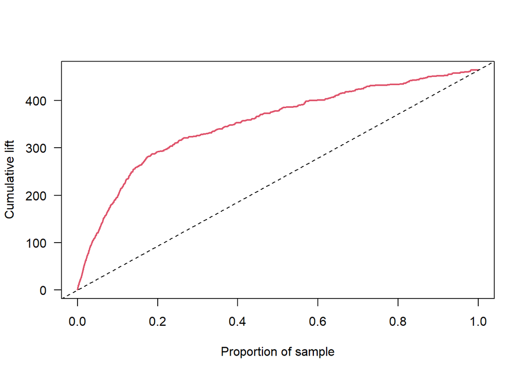

```r
bank_new_copy<-bank_new
prob <- predict(final_model,type = "response", newdata = bank_new)

bank_new_copy$prob<- prob

y <- na.omit(bank_new)$subscribed

# Function to compute lift and cumulative gain charts
lift <- function(prob, y, pos.class = NULL, cumulative = TRUE) {
  if (!all(sort(unique(y)) == c(0, 1))) {
    if (is.null(pos.class)) {
      stop("A value for `pos.class` is required whenever `y` is not a 0/1 ",
           "outcome.", call. = FALSE)
    }
  y <- ifelse(y == pos.class, 1, 0)
  }
  ord <- order(prob, decreasing = TRUE)
  prob <- prob[ord]
  y <- y[ord]
  prop <- seq_along(y) / length(y)
  lift <- if (isTRUE(cumulative)) {
    cumsum(y)
  } else {
    (cumsum(y) / seq_along(y)) / mean(y)
  }
  structure(list("lift" = lift, "prop" = prop, "cumulative" = cumulative,
                 "y" = y), class = "lift")
}

# Cumulative gain chart; what does this plot tell us?
l <- lift(prob, y = y, pos.class = "yes")
plot(l[["prop"]], l[["lift"]], type = "l",
     xlab = "Proportion of sample", ylab = "Cumulative lift",
     las = 1, lwd = 2, col = 2)
abline(0, sum(y == "yes"), lty = 2)
```

**8) Suppose the bank can only afford to reach out to 500 households (marketing campaigns can be expensive).**

**How could you use your model to identify which 500 of the 4,118 households they should market to?**

**Since you have access to the actual response values (in real life, you would not have access to this**

**information until after the campaign is over and the data have been updated to include the results), how**

**accurate was your model? In other words, how many of the 500 customers that you initially selected**

**actually subscribed to a term deposit? (There’s no wrong answer here, so don’t get hung up on poor**

**accuracy. It’s the journey, and what you learned along the way that’s important.)**

```r
bank_new_copy<-bank_new_copy%>%
  arrange(desc(prob))%>%
  mutate(prob_rnk = row_number(), final_class = if_else(prob_rnk<= 500, "yes", "no"))

temp<-bank_new_copy[bank_new_copy$final_class=="yes",]

#temp #Top 500 Customers to target

xtabs(~subscribed + final_class,temp)
```

```
##           final_class
## subscribed yes
##        no  267
##        yes 233
```